# Pràctica 1 - Regressió Lineal

Axel Romero

5/10/2020

```r
library(ISLR)
library(tidyverse)
library(car)
```

# 1 Exercici 1

El model de l’exemple és:
$$sales = \beta_0+\beta_1\times TV+\beta_2\times radio+\beta_3\times newspaper+\epsilon$$
Les hipòtesis nul·les són:
$H_0: \beta_0 = 0$
$H_0: \beta_1 = 0$
$H_0: \beta_2 = 0$
$H_0: \beta_3 = 0$

Com que el p-valor de $\beta_0$ ha donat significatiu, podem rebutjar que l’intercept té un valor de 0. Això vol dir que en el cas de no invertir en cap mitjà de comunicació hi hauria vendes.  
Després, el coeficient de TV també ha donat significatiu, així que la inversió en publicitat en TV té un afecte en les vendes, i de manera positiva. A la ràdio passa el mateix que en la TV, el p-valor dóna significatiu i per tant es pot rebutja la hipòtesi inicial que la inversió en publicitat en aquest mitjà no té un efecte en les vendes.  
El cas del diari és diferent, aquí el p-valor no és significatiu i per tant no podem rebutjar la hipòtesi nul·la. Concloem que la inversió en publicitat en aquest mitjà no té efectes en les vendes.

# 2 Exercici 2

Tenim una base de dades amb les següents variables:

- $X_1$: GPA.
- $X_2$: IQ.
- $X_3$: Sexe (1 per dones, 0 per homes).
- $X_4$: Interacció entre GPA i IQ.
- $X_5$: Interacció entre GPA i Sexe.
- $Y$: Primer salari després de la graduació (en milions de dòlars).

El model queda:
$$Y = \beta_0 + \beta_1 X_1 + \beta_2 X_2 + \beta_3 X_3 + \beta_4 X_4 + \beta_5 X_5$$

Les estimacions dels coeficients fetes amb mínims quadrats queden:  
$\hat\beta_0=50, \hat\beta_1=20, \hat\beta_2=0.07, \hat\beta_3=35, \hat\beta_4=0.01, \hat\beta_5=-10$

## 2.1 A.)

*Per un valor fix d’IQ i GPA, els homes guanyen més de mitjana que les dones, sempre que la GPA sigui prou alta.*

Si mantenim IQ i GPA constant:  
$E(y|X_1=c_1, X_2=c_2, X_3=0, X_4=c_3, X_5=0)=50+20\times c_1+0.07\times c_2+0.01\times c_3$  
$E(y|X_1=c_1, X_2=c_2, X_3=1, X_4=c_3, X_5=-10\times c_1)=50+20\times c_1+0.07\times c_2+35+0.01\times c_3-10\times c_1$

Si restem les dues esperances, veurem la diferència mitjana entre home i dona. Es veu que en el cas de ser dóna la diferència és de $35-10\times c_1$ amb els homes. Amb això es veu que si el valor de GPA és gran, els homes tindran un millor salari que les dones.

Les dues primeres opcions no són certes perquè en el model hi ha interacció. Aquestes afirmacions diuen que la diferència mitjana entre homes i dones és constant.

## 2.2 B.)

Predir el salari amb les dades: $X_1=4, X_2=110, X_3=1$  
$Salari=50+20\times4+0.07\times110+35+0.01\times(4\times110)-10\times4=137.1$

## 2.3 C.)

És cert que el valor de la interacció entre ‘IQ’ i ‘GPA’ és petit, el problema és saber si aquest efecte d’interacció és prou intens per a influir en les conclusions i per tant tenir en compte en el model.

Una manera de fer-ho és mitjançant gràfiques d’interacció. En aquestes gràfiques, com més perpendicular siguin les línies, més significativa és la interacció i contra més paral·leles siguin menys significativa és la interacció.

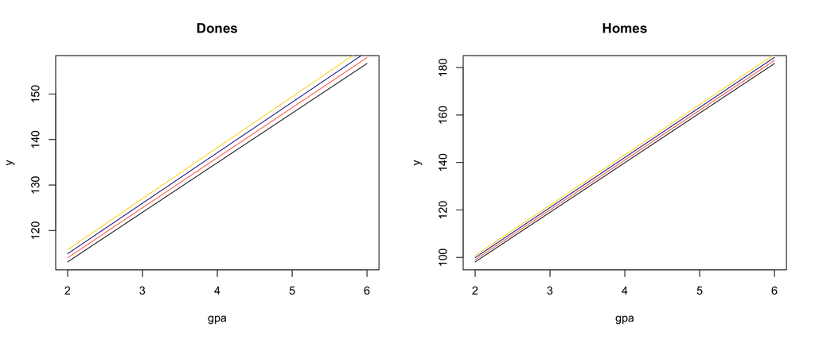

```r
iq <- c(90, 100, 110, 120)
sexe <- c(1, 0)

gpa <- seq(2, 6, by = .2)
func_y <- function(gpa, iq, sexe){
 50 + 20 * gpa + 0.07 * iq[1] + 35 * sexe[1] + 0.01 * gpa * iq[1] + -10 * gpa * sexe[1]
}

par(mfrow = c(1, 2))
plot(gpa, func_y(gpa, iq[1], sexe[1]), type = 'l', main = 'Dones',
     ylab = 'y')
lines(gpa, func_y(gpa, iq[2], sexe[1]), col = 'tomato')
lines(gpa, func_y(gpa, iq[3], sexe[1]), col = 'darkblue')
lines(gpa, func_y(gpa, iq[4], sexe[1]), col = 'gold')

plot(gpa, func_y(gpa, iq[1], sexe[2]), type = 'l', main = 'Homes',
     ylab = 'y')
lines(gpa, func_y(gpa, iq[2], sexe[2]), col = 'tomato')
lines(gpa, func_y(gpa, iq[3], sexe[2]), col = 'darkblue')
lines(gpa, func_y(gpa, iq[4], sexe[2]), col = 'gold')
```

```r
par(mfrow = c(1,1))
```

En aquestes gràfiques, les diferents línies són diferents valors de la variable ‘IQ’. Es pot observar que les línies són força paral·leles i, per tant, la interacció sembla no ser molt significativa. Per aquest motiu SÍ hi ha poques evidències de l’existència d’un efecte d’interacció.

# 3 Exercici 3

## 3.1 A.)

El model és:
$$mpg = \beta_0 + \beta_1 \times horsepower + \epsilon$$

```r
mod1 <- lm(mpg ~ horsepower, Auto)
(smod1 <- summary(mod1))
```

```
##
## Call:
## lm(formula = mpg ~ horsepower, data = Auto)
##
## Residuals:
##      Min       1Q   Median       3Q      Max
## -13.5710  -3.2592  -0.3435   2.7630  16.9240
##
## Coefficients:
##              Estimate Std. Error t value Pr(>|t|)
## (Intercept) 39.935861   0.717499   55.66   <2e-16 ***
## horsepower  -0.157845   0.006446  -24.49   <2e-16 ***
## ---
## Signif. codes:  0 '***' 0.001 '**' 0.01 '*' 0.05 '.' 0.1 ' ' 1
##
## Residual standard error: 4.906 on 390 degrees of freedom
## Multiple R-squared:  0.6059, Adjusted R-squared:  0.6049
## F-statistic: 599.7 on 1 and 390 DF,  p-value: < 2.2e-16
```

Sí que hi ha una certa relació entre el predictor ‘horsepower’ i la resposta ‘mpg’, ja que l’estimació de $\beta_1$ és diferent de $0$ significativament perquè el p-valor és més petit que $\alpha = 0.05$.

```r
cor(Auto$mpg, Auto$horsepower)
```

```
## [1] -0.7784268
```

Amb la correlació podem mesurar la intensitat de la relació entre les dues variables. Es veu que és una relació força intensa, ja que la correlació pren valors en l’interval [-1, 1].

La relació és negativa, perquè el signe de la correlació és negatiu. Això vol dir que la relació és inversa, a nivells grans de `horsepower` tenim valors petits de `mpg`.

Per a un valor de `horsepower` = 98, la predicció és:

- A mà  
  `mpg` = 39.936 - 0.1578 * `horsepower` = 24.4716
- Amb R

```r
predict(mod1, newdata = data.frame(horsepower = 98))
```

```
##        1
## 24.46708
```

Interval de confiança

```r
predict(mod1, newdata = data.frame(horsepower = 98), interval = 'confidence')
```

```
##        fit      lwr      upr
## 1 24.46708 23.97308 24.96108
```

Interval de predicció

```r
predict(mod1, newdata = data.frame(horsepower = 98), interval = 'prediction')
```

```
##        fit     lwr      upr
## 1 24.46708 14.8094 34.12476
```

## 3.2 B.)

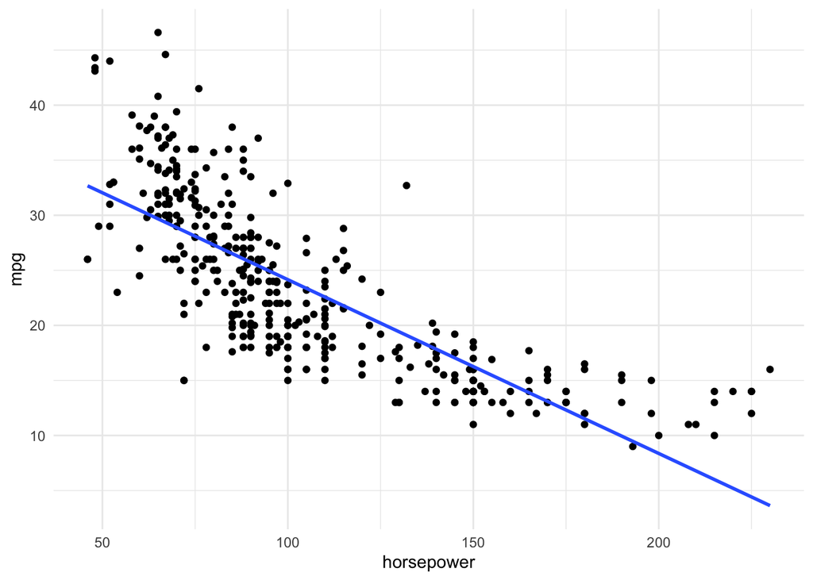

```r
ggplot(Auto, aes(x = horsepower, y = mpg)) +
  geom_point() + geom_smooth(method = 'lm', se = F) +
  theme_minimal()
```

## 3.3 C.)

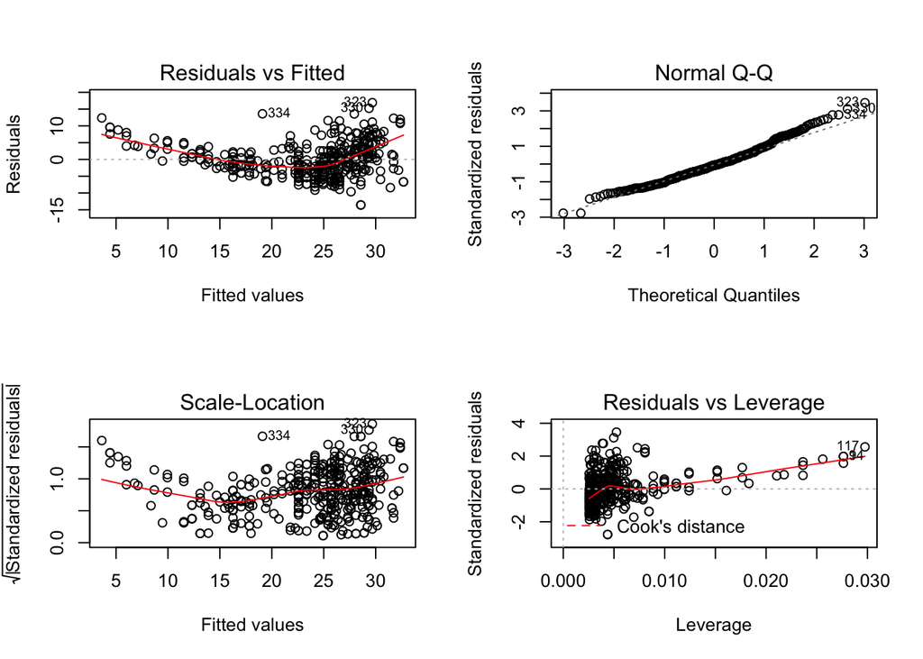

```r
par(mfrow = c(2, 2))
plot(mod1)
```

```r
par(mfrow = c(1, 1))
```

Amb la primera gràfica es pot veure que els residus presenta una mancança de linealitat, sobretot als extrems. El mateix es pot observar en la gràfica de les dades de l’apartat **B.)**. Després, amb la segona gràfica es pot veure que els residus sí que tenen una distribució normal, ja que no se separen molt de la bisectriu. Finalment, la tercera gràfica serveix per comprovar si hi ha igualtat de variàncies. Es pot veure que la línia vermella més o menys es manté en la recta horitzontal, passa igual que en la linealitat dels residus, hi ha mancança d’homocedasticitat als extrems.

Amb aquestes gràfiques es pot pensar que les dades no ajusten bé a una recta. Per comprovar-lo es pot fer el test de manca d’ajust lineal (*lof*).

```r
mod_PE <- lm(mpg ~ -1 + as.factor(horsepower), data = Auto)
lof <- anova(mod1, mod_PE)
lof
```

```
## Analysis of Variance Table
##
## Model 1: mpg ~ horsepower
## Model 2: mpg ~ -1 + as.factor(horsepower)
##   Res.Df    RSS Df Sum of Sq     F    Pr(>F)
## 1    390 9385.9
## 2    299 4702.8 91    4683.1 3.272 1.125e-14 ***
## ---
## Signif. codes:  0 '***' 0.001 '**' 0.01 '*' 0.05 '.' 0.1 ' ' 1
```

En aquest test el que volem és no rebutjar la hipòtesi nul·la, ja que aquesta ens diu que la variable resposta s’ajusta a una recta. Es veu que el p-valor dóna més petit que $\alpha$ i per tant rebutgem la hipòtesi nul·la. Això vol dir que les dades no s’ajusten bé a una recta.

# 4 Exercici 4

## 4.1 A.)

Fem un scatterplot que inclogui totes les variables de la base de dades `Auto`.

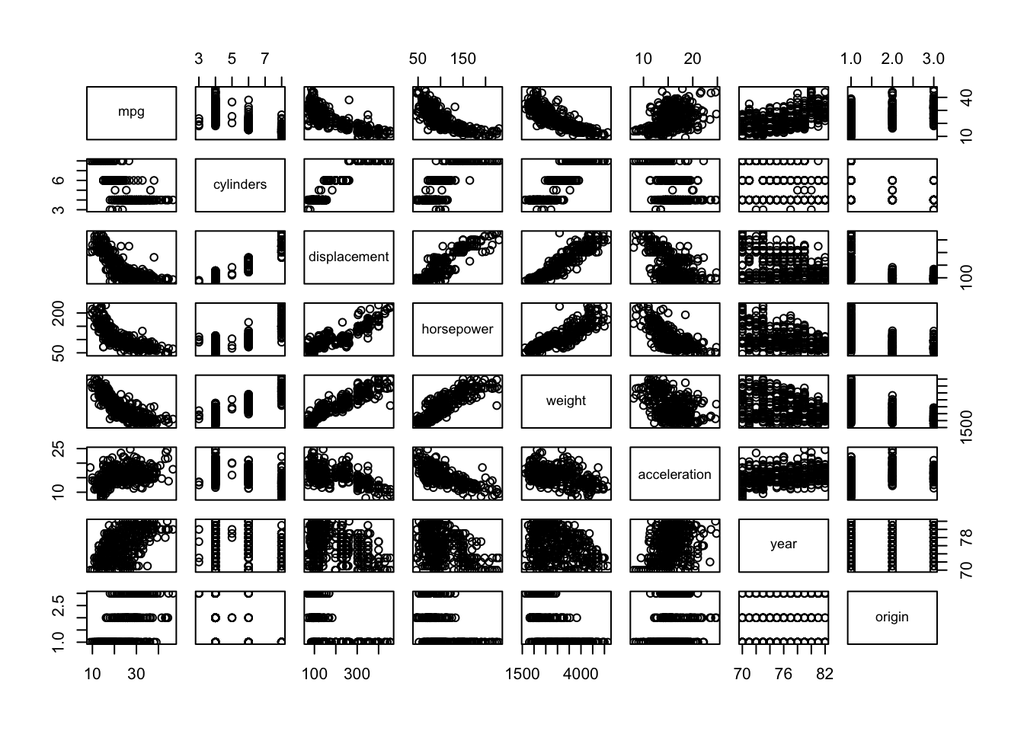

```r
Auto_new <- Auto[, -ncol(Auto)]
pairs(Auto_new)
```

## 4.2 B.)

Calculem la matriu de correlacions entre totes les variables.

```r
cor(Auto_new)
```

```
##                     mpg  cylinders displacement horsepower     weight
## mpg           1.0000000 -0.7776175   -0.8051269 -0.7784268 -0.8322442
## cylinders    -0.7776175  1.0000000    0.9508233  0.8429834  0.8975273
## displacement -0.8051269  0.9508233    1.0000000  0.8972570  0.9329944
## horsepower   -0.7784268  0.8429834    0.8972570  1.0000000  0.8645377
## weight       -0.8322442  0.8975273    0.9329944  0.8645377  1.0000000
## acceleration  0.4233285 -0.5046834   -0.5438005 -0.6891955 -0.4168392
## year          0.5805410 -0.3456474   -0.3698552 -0.4163615 -0.3091199
## origin        0.5652088 -0.5689316   -0.6145351 -0.4551715 -0.5850054
##              acceleration       year     origin
## mpg             0.4233285  0.5805410  0.5652088
## cylinders      -0.5046834 -0.3456474 -0.5689316
## displacement   -0.5438005 -0.3698552 -0.6145351
## horsepower     -0.6891955 -0.4163615 -0.4551715
## weight         -0.4168392 -0.3091199 -0.5850054
## acceleration    1.0000000  0.2903161  0.2127458
## year            0.2903161  1.0000000  0.1815277
## origin          0.2127458  0.1815277  1.0000000
```

Es poden destacar correlacions molt altes, com per exemple la que hi ha entre `displacement` i `cylinders` que té un valor de 0.95. Després, dues variables amb correlació molt propera a 0, són `origin` i `year`, on la correlació té un valor de 0.1815.

## 4.3 C.)

```r
mod2 <- lm(mpg ~., data = Auto_new)
(smod2 <- summary(mod2))
```

```
##
## Call:
## lm(formula = mpg ~ ., data = Auto_new)
##
## Residuals:
##     Min      1Q  Median      3Q     Max
## -9.5903 -2.1565 -0.1169  1.8690 13.0604
##
## Coefficients:
##                Estimate Std. Error t value Pr(>|t|)
## (Intercept)  -17.218435   4.644294  -3.707  0.00024 ***
## cylinders     -0.493376   0.323282  -1.526  0.12780
## displacement   0.019896   0.007515   2.647  0.00844 **
## horsepower    -0.016951   0.013787  -1.230  0.21963
## weight        -0.006474   0.000652  -9.929  < 2e-16 ***
## acceleration   0.080576   0.098845   0.815  0.41548
## year           0.750773   0.050973  14.729  < 2e-16 ***
## origin         1.426141   0.278136   5.127 4.67e-07 ***
## ---
## Signif. codes:  0 '***' 0.001 '**' 0.01 '*' 0.05 '.' 0.1 ' ' 1
##
## Residual standard error: 3.328 on 384 degrees of freedom
## Multiple R-squared:  0.8215, Adjusted R-squared:  0.8182
## F-statistic: 252.4 on 7 and 384 DF,  p-value: < 2.2e-16
```

Sí que hi ha una relació entre els predictors i la variable resposta, ja que el valor del $R^2$ ajustat és bastant elevat. També es pot observar que hi ha diverses variables que són significativament diferents de 0, i per tant tenen un efecte en la variable resposta.

Les variables que semblen tenir una associació significativa amb la resposta són: `displacement`, `weight`, `year` i `origin`. La resta de variables semblen ser no significatives, però si es volen treure del model, s’ha de fer d’una en una.

EL coeficient de la variable `year` és $\hat\beta_6 = 0.751$, que al ser positiu ens diu que els cotxes més nous tenen un rendiment (mpg) superior. Els cotxes moderns tenen menor consum que els antics.

Ara fem les gràfiques de diagnòstic dels residus.

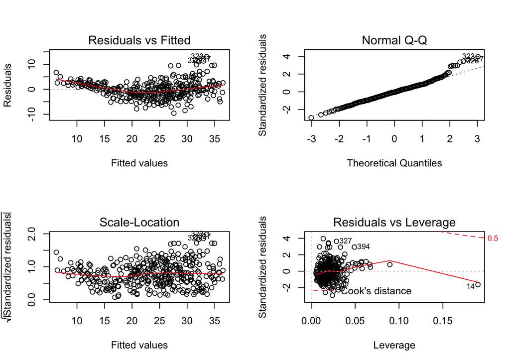

```r
par(mfrow = c(2, 2))
plot(mod2)
```

```r
par(mfrow = c(1, 1))
```

En el primer gràfic es veu que hi ha un cert patró però està al voltant del 0 i a més és de poca intensitat. Es pot dir que els residus estan centrats en el 0 i per tant tenen una forma lineal. Després, es compleix que els residus són normals, ja que en el qq-plot els residus estan en la bisectriu, només hi ha algunes desviacions a l’extrem dret. Finalment, amb el tercer gràfic es veu que hi ha homocedasticitat, ja que no hi ha cap patró i tots els valors estan distribuïts al voltant del zero.

Amb això es veu que les hipòtesis principals del model lineal es compleixen.

# 5 Exercici 5

## 5.1 A.)

El model de regressió múltiple és:
$$Sales = \beta_0 + \beta_1 \times Price + \beta_2 \times Urban + \beta_3 \times US + \epsilon$$
Les variables són:

- `Sales`: nombre (en milers) de cadires de cotxe per a nens venudes.
- `Price`: preu de la cadira.
- `Urban`: si la botiga és o no a una zona urbana. (Variable binària amb valors *Yes* i *No*)
- `US`: si la botiga està o no als EUA. (Variable binària amb valors *Yes* i *No*)

Cada fila és una botiga diferent.

```r
mod3 <- lm(Sales ~ Price + Urban + US, data = Carseats)
(smod3 <- summary(mod3))
```

```
##
## Call:
## lm(formula = Sales ~ Price + Urban + US, data = Carseats)
##
## Residuals:
##     Min      1Q  Median      3Q     Max
## -6.9206 -1.6220 -0.0564  1.5786  7.0581
##
## Coefficients:
##              Estimate Std. Error t value Pr(>|t|)
## (Intercept) 13.043469   0.651012  20.036  < 2e-16 ***
## Price       -0.054459   0.005242 -10.389  < 2e-16 ***
## UrbanYes    -0.021916   0.271650  -0.081    0.936
## USYes        1.200573   0.259042   4.635 4.86e-06 ***
## ---
## Signif. codes:  0 '***' 0.001 '**' 0.01 '*' 0.05 '.' 0.1 ' ' 1
##
## Residual standard error: 2.472 on 396 degrees of freedom
## Multiple R-squared:  0.2393, Adjusted R-squared:  0.2335
## F-statistic: 41.52 on 3 and 396 DF,  p-value: < 2.2e-16
```

## 5.2 B.)

En aquest model la variable `Urban` no és significativa, ja que el p-valor és més gran que $\alpha = 0.05$. Això ens diu que aquesta variable no té una associació significativa amb la variable resposta `Sales`. La resta de variables sí que tenen una associació significativa amb `Sales`. D’aquestes dues, en `Price` es veu que el coeficient és negatiu, i per tant la relació entre `Price` i `Sales` és negativa, a preu més elevat menys vendes. Després la variable `US` té un coeficient positiu així que té una relació directa, el fet que la tenda estigui en els EUA fa que les vendes augmentin.

## 5.3 C.)

Pel predictor `Urban`, el seu coeficient no és significatiu, és a dir que el fet que la tenda estigui en zona urbana no afecta a la quantitat de vendes.

## 5.4 D.)

Ara el model queda:
$$Sales = \beta_0 + \beta_1 \times Price + \beta_2 \times US + \epsilon$$

```r
mod4 <- lm(Sales ~ Price + US, data = Carseats)
(smod4 <- summary(mod4))
```

```
##
## Call:
## lm(formula = Sales ~ Price + US, data = Carseats)
##
## Residuals:
##     Min      1Q  Median      3Q     Max
## -6.9269 -1.6286 -0.0574  1.5766  7.0515
##
## Coefficients:
##             Estimate Std. Error t value Pr(>|t|)
## (Intercept) 13.03079    0.63098  20.652  < 2e-16 ***
## Price       -0.05448    0.00523 -10.416  < 2e-16 ***
## USYes        1.19964    0.25846   4.641 4.71e-06 ***
## ---
## Signif. codes:  0 '***' 0.001 '**' 0.01 '*' 0.05 '.' 0.1 ' ' 1
##
## Residual standard error: 2.469 on 397 degrees of freedom
## Multiple R-squared:  0.2393, Adjusted R-squared:  0.2354
## F-statistic: 62.43 on 2 and 397 DF,  p-value: < 2.2e-16
```

En aquest model tots els coeficients són significatius i a més el $R^2$ no es veu afectat, es manté pràcticament igual.

## 5.5 E.)

```r
anova(mod3, mod4)
```

```
## Analysis of Variance Table
##
## Model 1: Sales ~ Price + Urban + US
## Model 2: Sales ~ Price + US
##   Res.Df    RSS Df Sum of Sq      F Pr(>F)
## 1    396 2420.8
## 2    397 2420.9 -1  -0.03979 0.0065 0.9357
```

Amb el p-valor es veu que no podem rebutjar la hipòtesi nul·la que els dos models ajusten d’igual manera. Com que no hi ha cap superior triem el segon pel principi de parsimònia, ja que té menys variables. És el mateix que s’havia comentat a l’apartat anterior, els dos $R^2$ tenen valors similars i per tant no hi ha diferència en la qualitat de l’ajust.

## 5.6 F.)

Ens quedem amb el model reduït de l’apartat **D.)**. Calculem l’interval de confiança pels coeficients amb un 95% de confiança.

```r
confint(mod4)
```

```
##                   2.5 %      97.5 %
## (Intercept) 11.79032020 14.27126531
## Price       -0.06475984 -0.04419543
## USYes        0.69151957  1.70776632
```

### 5.6.1 G.)

```r
outlierTest(mod4)
```

```
## No Studentized residuals with Bonferroni p < 0.05
## Largest |rstudent|:
##     rstudent unadjusted p-value Bonferroni p
## 377 2.891521          0.0040452           NA
```

# 6 Exercici 6

## 6.1 A.)

Simulació del vector $X$, tal que $X \sim N(0, 1)$.

```r
set.seed(1)
x <- rnorm(100)
x
```

```
##   [1] -0.626453811  0.183643324 -0.835628612  1.595280802  0.329507772
##   [6] -0.820468384  0.487429052  0.738324705  0.575781352 -0.305388387
##  [11]  1.511781168  0.389843236 -0.621240581 -2.214699887  1.124930918
##  [16] -0.044933609 -0.016190263  0.943836211  0.821221195  0.593901321
##  [21]  0.918977372  0.782136301  0.074564983 -1.989351696  0.619825748
##  [26] -0.056128740 -0.155795507 -1.470752384 -0.478150055  0.417941560
##  [31]  1.358679552 -0.102787727  0.387671612 -0.053805041 -1.377059557
##  [36] -0.414994563 -0.394289954 -0.059313397  1.100025372  0.763175748
##  [41] -0.164523596 -0.253361680  0.696963375  0.556663199 -0.688755695
##  [46] -0.707495157  0.364581962  0.768532925 -0.112346212  0.881107726
##  [51]  0.398105880 -0.612026393  0.341119691 -1.129363096  1.433023702
##  [56]  1.980399899 -0.367221476 -1.044134626  0.569719627 -0.135054604
##  [61]  2.401617761 -0.039240003  0.689739362  0.028002159 -0.743273209
##  [66]  0.188792300 -1.804958629  1.465554862  0.153253338  2.172611670
##  [71]  0.475509529 -0.709946431  0.610726353 -0.934097632 -1.253633400
##  [76]  0.291446236 -0.443291873  0.001105352  0.074341324 -0.589520946
##  [81] -0.568668733 -0.135178615  1.178086997 -1.523566800  0.593946188
##  [86]  0.332950371  1.063099837 -0.304183924  0.370018810  0.267098791
##  [91] -0.542520031  1.207867806  1.160402616  0.700213650  1.586833455
##  [96]  0.558486426 -1.276592208 -0.573265414 -1.224612615 -0.473400636
```

## 6.2 B.)

Simulem un vector `eps` amb els errors, $eps \sim N(0, 0.25)$.

```r
eps <- rnorm(100, 0, 0.25)
eps
```

```
##   [1] -0.155091669  0.010528968 -0.227730412  0.039507193 -0.163646161
##   [6]  0.441821817  0.179176869  0.227543557  0.096046339  0.420544020
##  [11] -0.158934113 -0.115411183  0.358070560 -0.162674088 -0.051845186
##  [16] -0.098201982 -0.079998217 -0.069778326  0.123547083 -0.044332621
##  [21] -0.126489366  0.335759706 -0.053644852 -0.044889133 -0.025047685
##  [26]  0.178166577 -0.018391101 -0.009408543 -0.170415120 -0.081067568
##  [31]  0.015040110 -0.147223622  0.132874048 -0.379598520  0.076639465
##  [36] -0.384112456 -0.075244032 -0.132069976 -0.163023695 -0.014224194
##  [41] -0.478589856  0.294145828 -0.416243109 -0.115882600 -0.278980026
##  [46] -0.187704750  0.521791636  0.004348905 -0.321575133 -0.410151384
##  [51]  0.112546775 -0.004639958 -0.079517094 -0.232340537 -0.371865078
##  [56] -0.268798074  0.250007201 -0.155316674 -0.346106712  0.467322656
##  [61]  0.106275094 -0.059661775  0.264620762  0.221605663 -0.154810762
##  [66]  0.551525616 -0.063756758 -0.356123663 -0.036099900  0.051884585
##  [71]  0.576994600  0.026450592  0.114249701 -0.019288234 -0.083500211
##  [76] -0.008681507  0.196909901  0.518811252  0.256848110  0.301977100
##  [81] -0.307830855  0.245973893  0.054981201 -0.366812507  0.130255686
##  [86] -0.039688651  0.366146828 -0.191520500 -0.107552938 -0.231527374
##  [91] -0.044275990  0.100502945 -0.182937043  0.207593292 -0.302020697
##  [96] -0.261996103  0.360289427 -0.253961866  0.102993678 -0.095269013
```

## 6.3 C.)

Generem el vector $Y$ a partir del model:  
$Y = -1 + 0.5X + \epsilon$

```r
y <- -1 + 0.5 * x +  eps
y
```

```
##   [1] -1.4683186 -0.8976494 -1.6455447 -0.1628524 -0.9988923 -0.9684124
##   [7] -0.5771086 -0.4032941 -0.6160630 -0.7321502 -0.4030435 -0.9204896
##  [13] -0.9525497 -2.2700240 -0.4893797 -1.1206688 -1.0880933 -0.5978602
##  [19] -0.4658423 -0.7473820 -0.6670007 -0.2731721 -1.0163624 -2.0395650
##  [25] -0.7151348 -0.8498978 -1.0962889 -1.7447847 -1.4094901 -0.8720968
##  [31] -0.3056201 -1.1986175 -0.6732901 -1.4065010 -1.6118903 -1.5916097
##  [37] -1.2723890 -1.1617267 -0.6130110 -0.6326363 -1.5608517 -0.8325350
##  [43] -1.0677614 -0.8375510 -1.6233579 -1.5414523 -0.2959174 -0.6113846
##  [49] -1.3777482 -0.9695975 -0.6884003 -1.3106532 -0.9089572 -1.7970221
##  [55] -0.6553532 -0.2785981 -0.9336035 -1.6773840 -1.0612469 -0.6002046
##  [61]  0.3070840 -1.0792818 -0.3905096 -0.7643933 -1.5264474 -0.3540782
##  [67] -1.9662361 -0.6233462 -0.9594732  0.1381904 -0.1852506 -1.3285226
##  [73] -0.5803871 -1.4863370 -1.7103169 -0.8629584 -1.0247360 -0.4806361
##  [79] -0.7059812 -0.9927834 -1.5921652 -0.8216154 -0.3559753 -2.1285959
##  [85] -0.5727712 -0.8732135 -0.1023033 -1.3436125 -0.9225435 -1.0979780
##  [91] -1.3155360 -0.2955632 -0.6027357 -0.4422999 -0.5086040 -0.9827529
##  [97] -1.2780067 -1.5405946 -1.5093126 -1.3319693
```

## 6.4 D.)

```r
length(y)
```

```
## [1] 100
```

La longitud del vector $Y$ és de 100.  
En aquest cas, els valors dels coeficients són: $\hat\beta_0 \approx -1$ i $\hat\beta_1 \approx 0.5$.

## 6.5 E.)

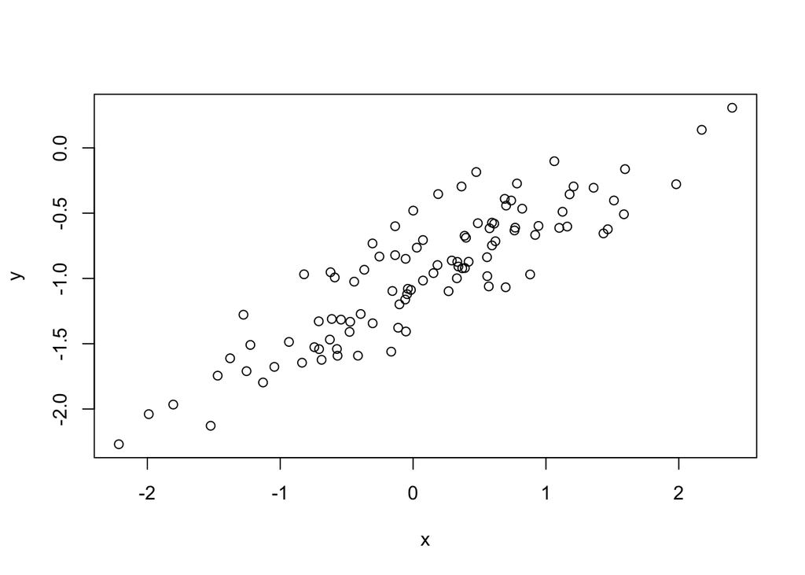

```r
plot(y ~ x)
```

## 6.6 F.)

```r
mod5 <-  lm(y ~ x)
summary(mod5)
```

```
##
## Call:
## lm(formula = y ~ x)
##
## Residuals:
##      Min       1Q   Median       3Q      Max
## -0.46921 -0.15344 -0.03487  0.13485  0.58654
##
## Coefficients:
##             Estimate Std. Error t value Pr(>|t|)
## (Intercept) -1.00942    0.02425  -41.63   <2e-16 ***
## x            0.49973    0.02693   18.56   <2e-16 ***
## ---
## Signif. codes:  0 '***' 0.001 '**' 0.01 '*' 0.05 '.' 0.1 ' ' 1
##
## Residual standard error: 0.2407 on 98 degrees of freedom
## Multiple R-squared:  0.7784, Adjusted R-squared:  0.7762
## F-statistic: 344.3 on 1 and 98 DF,  p-value: < 2.2e-16
```

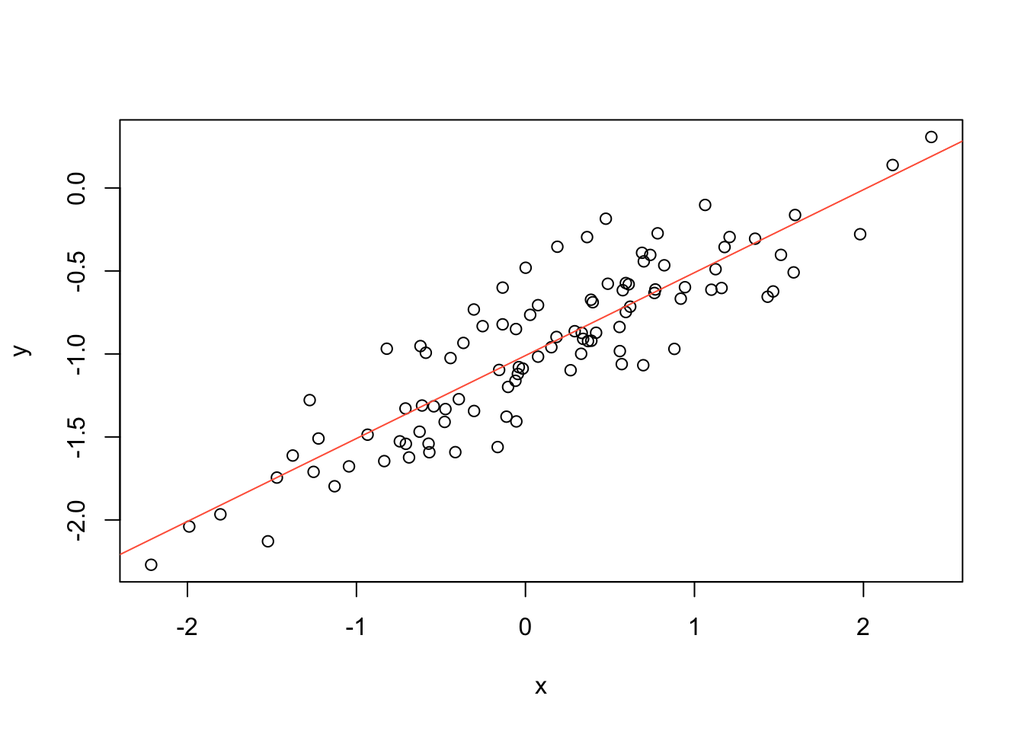

```r
plot(y ~ x)
abline(mod5, col = 'tomato')
```

### 6.6.1 G.)

Ara ajustem les dades a un polinomi de segon grau.

```r
mod6 <- lm(y ~ x +  I(x^2))
summary(mod6)
```

```
##
## Call:
## lm(formula = y ~ x + I(x^2))
##
## Residuals:
##     Min      1Q  Median      3Q     Max
## -0.4913 -0.1563 -0.0322  0.1451  0.5675
##
## Coefficients:
##             Estimate Std. Error t value Pr(>|t|)
## (Intercept) -0.98582    0.02941 -33.516   <2e-16 ***
## x            0.50429    0.02700  18.680   <2e-16 ***
## I(x^2)      -0.02973    0.02119  -1.403    0.164
## ---
## Signif. codes:  0 '***' 0.001 '**' 0.01 '*' 0.05 '.' 0.1 ' ' 1
##
## Residual standard error: 0.2395 on 97 degrees of freedom
## Multiple R-squared:  0.7828, Adjusted R-squared:  0.7784
## F-statistic: 174.8 on 2 and 97 DF,  p-value: < 2.2e-16
```

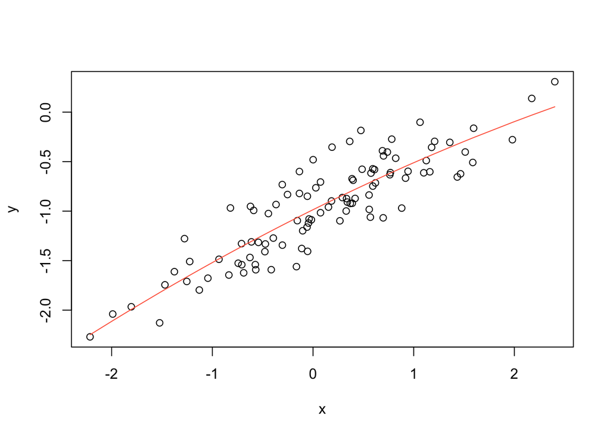

```r
plot(y ~ x)
lines(sort(x), predict(mod6, newdata = data.frame(x = sort(x))),  col = 'tomato')
```

Es veu que el coeficient del terme quadràtic és no significatiu, i això és degut al fet que les dades visualment no presenten forma quadràtica. En fer la representació gràfica es veu que l’efecte del terme quadràtic és quasi nul i la recta no varia molt respecte a la del model lineal de l’apartat anterior.